# Risk Factor Analysis

## Outcome Variable

**Outcome Variable:** stunted

## Predictor Variables

**Intervention Variable:** birthlen

**Adjustment Set:**

- arm
- sex
- W_mage
- meducyrs
- feducyrs
- vagbrth
- single
- brthmon
- W_parity
- impsan
- delta_W_mage
- delta_meducyrs
- delta_feducyrs
- delta_vagbrth
- delta_single
- delta_brthmon
- delta_W_parity
- delta_impsan

## Stratifying Variables

The analysis was stratified on these variable(s):

- agecat
- studyid
- country

## Data Summary

| agecat | studyid | country | birthlen | stunted | n_cell | n |
| --- | --- | --- | --- | --- | --- | --- |
| Birth | ki0047075b-MAL-ED | BANGLADESH | >=50 cm | 0 | 29 | 257 |
| Birth | ki0047075b-MAL-ED | BANGLADESH | >=50 cm | 1 | 0 | 257 |
| Birth | ki0047075b-MAL-ED | BANGLADESH | <48 cm | 0 | 97 | 257 |
| Birth | ki0047075b-MAL-ED | BANGLADESH | <48 cm | 1 | 47 | 257 |
| Birth | ki0047075b-MAL-ED | BANGLADESH | [48-50) cm | 0 | 84 | 257 |
| Birth | ki0047075b-MAL-ED | BANGLADESH | [48-50) cm | 1 | 0 | 257 |
| Birth | ki0047075b-MAL-ED | BRAZIL | >=50 cm | 0 | 34 | 191 |
| Birth | ki0047075b-MAL-ED | BRAZIL | >=50 cm | 1 | 0 | 191 |
| Birth | ki0047075b-MAL-ED | BRAZIL | <48 cm | 0 | 59 | 191 |
| Birth | ki0047075b-MAL-ED | BRAZIL | <48 cm | 1 | 21 | 191 |
| Birth | ki0047075b-MAL-ED | BRAZIL | [48-50) cm | 0 | 77 | 191 |
| Birth | ki0047075b-MAL-ED | BRAZIL | [48-50) cm | 1 | 0 | 191 |
| Birth | ki0047075b-MAL-ED | INDIA | >=50 cm | 0 | 25 | 206 |
| Birth | ki0047075b-MAL-ED | INDIA | >=50 cm | 1 | 0 | 206 |
| Birth | ki0047075b-MAL-ED | INDIA | <48 cm | 0 | 74 | 206 |
| Birth | ki0047075b-MAL-ED | INDIA | <48 cm | 1 | 33 | 206 |
| Birth | ki0047075b-MAL-ED | INDIA | [48-50) cm | 0 | 74 | 206 |
| Birth | ki0047075b-MAL-ED | INDIA | [48-50) cm | 1 | 0 | 206 |
| Birth | ki0047075b-MAL-ED | NEPAL | >=50 cm | 0 | 38 | 173 |
| Birth | ki0047075b-MAL-ED | NEPAL | >=50 cm | 1 | 0 | 173 |
| Birth | ki0047075b-MAL-ED | NEPAL | <48 cm | 0 | 51 | 173 |
| Birth | ki0047075b-MAL-ED | NEPAL | <48 cm | 1 | 18 | 173 |
| Birth | ki0047075b-MAL-ED | NEPAL | [48-50) cm | 0 | 66 | 173 |
| Birth | ki0047075b-MAL-ED | NEPAL | [48-50) cm | 1 | 0 | 173 |
| Birth | ki0047075b-MAL-ED | PERU | >=50 cm | 0 | 34 | 287 |
| Birth | ki0047075b-MAL-ED | PERU | >=50 cm | 1 | 0 | 287 |
| Birth | ki0047075b-MAL-ED | PERU | <48 cm | 0 | 108 | 287 |
| Birth | ki0047075b-MAL-ED | PERU | <48 cm | 1 | 34 | 287 |
| Birth | ki0047075b-MAL-ED | PERU | [48-50) cm | 0 | 111 | 287 |
| Birth | ki0047075b-MAL-ED | PERU | [48-50) cm | 1 | 0 | 287 |

[output cut: 432 more lines]

The following strata were considered:

- agecat: 24 months, studyid: ki0047075b-MAL-ED, country: BANGLADESH
- agecat: 24 months, studyid: ki0047075b-MAL-ED, country: BRAZIL
- agecat: 24 months, studyid: ki0047075b-MAL-ED, country: INDIA
- agecat: 24 months, studyid: ki0047075b-MAL-ED, country: NEPAL
- agecat: 24 months, studyid: ki0047075b-MAL-ED, country: PERU
- agecat: 24 months, studyid: ki0047075b-MAL-ED, country: SOUTH AFRICA
- agecat: 24 months, studyid: ki0047075b-MAL-ED, country: TANZANIA, UNITED REPUBLIC OF
- agecat: 24 months, studyid: ki1000108-CMC-V-BCS-2002, country: INDIA
- agecat: 24 months, studyid: ki1000108-IRC, country: INDIA
- agecat: 24 months, studyid: ki1017093-NIH-Birth, country: BANGLADESH
- agecat: 24 months, studyid: ki1017093b-PROVIDE, country: BANGLADESH
- agecat: 24 months, studyid: ki1017093c-NIH-Crypto, country: BANGLADESH
- agecat: 24 months, studyid: ki1101329-Keneba, country: GAMBIA
- agecat: 24 months, studyid: ki1114097-CMIN, country: BANGLADESH
- agecat: 24 months, studyid: ki1114097-CMIN, country: PERU
- agecat: 24 months, studyid: ki1114097-CONTENT, country: PERU
- agecat: 24 months, studyid: ki1119695-PROBIT, country: BELARUS
- agecat: 24 months, studyid: ki1126311-ZVITAMBO, country: ZIMBABWE
- agecat: 24 months, studyid: ki1135781-COHORTS, country: GUATEMALA
- agecat: 24 months, studyid: ki1135781-COHORTS, country: INDIA
- agecat: 24 months, studyid: ki1135781-COHORTS, country: PHILIPPINES
- agecat: 24 months, studyid: kiGH5241-JiVitA-3, country: BANGLADESH
- agecat: 24 months, studyid: kiGH5241-JiVitA-4, country: BANGLADESH
- agecat: 6 months, studyid: ki0047075b-MAL-ED, country: BANGLADESH
- agecat: 6 months, studyid: ki0047075b-MAL-ED, country: BRAZIL
- agecat: 6 months, studyid: ki0047075b-MAL-ED, country: INDIA
- agecat: 6 months, studyid: ki0047075b-MAL-ED, country: NEPAL
- agecat: 6 months, studyid: ki0047075b-MAL-ED, country: PERU
- agecat: 6 months, studyid: ki0047075b-MAL-ED, country: SOUTH AFRICA
- agecat: 6 months, studyid: ki0047075b-MAL-ED, country: TANZANIA, UNITED REPUBLIC OF
- agecat: 6 months, studyid: ki1000108-CMC-V-BCS-2002, country: INDIA
- agecat: 6 months, studyid: ki1000108-IRC, country: INDIA
- agecat: 6 months, studyid: ki1000109-EE, country: PAKISTAN
- agecat: 6 months, studyid: ki1000109-ResPak, country: PAKISTAN
- agecat: 6 months, studyid: ki1000304b-SAS-CompFeed, country: INDIA
- agecat: 6 months, studyid: ki1017093-NIH-Birth, country: BANGLADESH
- agecat: 6 months, studyid: ki1017093b-PROVIDE, country: BANGLADESH
- agecat: 6 months, studyid: ki1017093c-NIH-Crypto, country: BANGLADESH
- agecat: 6 months, studyid: ki1101329-Keneba, country: GAMBIA
- agecat: 6 months, studyid: ki1114097-CMIN, country: BANGLADESH
- agecat: 6 months, studyid: ki1114097-CMIN, country: BRAZIL
- agecat: 6 months, studyid: ki1114097-CMIN, country: GUINEA-BISSAU
- agecat: 6 months, studyid: ki1114097-CMIN, country: PERU
- agecat: 6 months, studyid: ki1114097-CONTENT, country: PERU
- agecat: 6 months, studyid: ki1119695-PROBIT, country: BELARUS
- agecat: 6 months, studyid: ki1126311-ZVITAMBO, country: ZIMBABWE
- agecat: 6 months, studyid: ki1135781-COHORTS, country: GUATEMALA
- agecat: 6 months, studyid: ki1135781-COHORTS, country: INDIA
- agecat: 6 months, studyid: ki1135781-COHORTS, country: PHILIPPINES
- agecat: 6 months, studyid: kiGH5241-JiVitA-3, country: BANGLADESH
- agecat: 6 months, studyid: kiGH5241-JiVitA-4, country: BANGLADESH
- agecat: Birth, studyid: ki0047075b-MAL-ED, country: BANGLADESH
- agecat: Birth, studyid: ki0047075b-MAL-ED, country: BRAZIL
- agecat: Birth, studyid: ki0047075b-MAL-ED, country: INDIA
- agecat: Birth, studyid: ki0047075b-MAL-ED, country: NEPAL
- agecat: Birth, studyid: ki0047075b-MAL-ED, country: PERU
- agecat: Birth, studyid: ki0047075b-MAL-ED, country: SOUTH AFRICA
- agecat: Birth, studyid: ki0047075b-MAL-ED, country: TANZANIA, UNITED REPUBLIC OF
- agecat: Birth, studyid: ki1000108-CMC-V-BCS-2002, country: INDIA
- agecat: Birth, studyid: ki1000108-IRC, country: INDIA
- agecat: Birth, studyid: ki1000109-EE, country: PAKISTAN
- agecat: Birth, studyid: ki1000109-ResPak, country: PAKISTAN
- agecat: Birth, studyid: ki1000304b-SAS-CompFeed, country: INDIA
- agecat: Birth, studyid: ki1017093-NIH-Birth, country: BANGLADESH
- agecat: Birth, studyid: ki1017093c-NIH-Crypto, country: BANGLADESH
- agecat: Birth, studyid: ki1101329-Keneba, country: GAMBIA
- agecat: Birth, studyid: ki1114097-CMIN, country: BANGLADESH
- agecat: Birth, studyid: ki1114097-CMIN, country: BRAZIL
- agecat: Birth, studyid: ki1114097-CMIN, country: PERU
- agecat: Birth, studyid: ki1114097-CONTENT, country: PERU
- agecat: Birth, studyid: ki1119695-PROBIT, country: BELARUS
- agecat: Birth, studyid: ki1126311-ZVITAMBO, country: ZIMBABWE
- agecat: Birth, studyid: ki1135781-COHORTS, country: GUATEMALA
- agecat: Birth, studyid: ki1135781-COHORTS, country: INDIA
- agecat: Birth, studyid: ki1135781-COHORTS, country: PHILIPPINES
- agecat: Birth, studyid: kiGH5241-JiVitA-3, country: BANGLADESH
- agecat: Birth, studyid: kiGH5241-JiVitA-4, country: BANGLADESH

### Dropped Strata

Some strata were dropped due to rare outcomes:

- agecat: Birth, studyid: ki0047075b-MAL-ED, country: BANGLADESH
- agecat: Birth, studyid: ki0047075b-MAL-ED, country: BRAZIL
- agecat: Birth, studyid: ki0047075b-MAL-ED, country: INDIA
- agecat: Birth, studyid: ki0047075b-MAL-ED, country: NEPAL
- agecat: Birth, studyid: ki0047075b-MAL-ED, country: PERU
- agecat: Birth, studyid: ki0047075b-MAL-ED, country: SOUTH AFRICA
- agecat: Birth, studyid: ki0047075b-MAL-ED, country: TANZANIA, UNITED REPUBLIC OF
- agecat: Birth, studyid: ki1000108-CMC-V-BCS-2002, country: INDIA
- agecat: Birth, studyid: ki1000108-IRC, country: INDIA
- agecat: Birth, studyid: ki1000109-EE, country: PAKISTAN
- agecat: Birth, studyid: ki1000109-ResPak, country: PAKISTAN
- agecat: Birth, studyid: ki1000304b-SAS-CompFeed, country: INDIA
- agecat: Birth, studyid: ki1017093-NIH-Birth, country: BANGLADESH
- agecat: Birth, studyid: ki1017093c-NIH-Crypto, country: BANGLADESH
- agecat: Birth, studyid: ki1101329-Keneba, country: GAMBIA
- agecat: Birth, studyid: ki1114097-CMIN, country: BANGLADESH
- agecat: Birth, studyid: ki1114097-CMIN, country: BRAZIL
- agecat: Birth, studyid: ki1114097-CMIN, country: PERU
- agecat: Birth, studyid: ki1114097-CONTENT, country: PERU
- agecat: Birth, studyid: ki1119695-PROBIT, country: BELARUS
- agecat: Birth, studyid: ki1126311-ZVITAMBO, country: ZIMBABWE
- agecat: Birth, studyid: ki1135781-COHORTS, country: GUATEMALA
- agecat: Birth, studyid: ki1135781-COHORTS, country: INDIA
- agecat: Birth, studyid: ki1135781-COHORTS, country: PHILIPPINES
- agecat: Birth, studyid: kiGH5241-JiVitA-3, country: BANGLADESH
- agecat: Birth, studyid: kiGH5241-JiVitA-4, country: BANGLADESH
- agecat: 6 months, studyid: ki0047075b-MAL-ED, country: BANGLADESH
- agecat: 6 months, studyid: ki0047075b-MAL-ED, country: BRAZIL
- agecat: 6 months, studyid: ki0047075b-MAL-ED, country: INDIA
- agecat: 6 months, studyid: ki0047075b-MAL-ED, country: NEPAL
- agecat: 6 months, studyid: ki0047075b-MAL-ED, country: PERU
- agecat: 6 months, studyid: ki0047075b-MAL-ED, country: SOUTH AFRICA
- agecat: 6 months, studyid: ki0047075b-MAL-ED, country: TANZANIA, UNITED REPUBLIC OF
- agecat: 6 months, studyid: ki1000109-EE, country: PAKISTAN
- agecat: 6 months, studyid: ki1000109-ResPak, country: PAKISTAN
- agecat: 6 months, studyid: ki1017093-NIH-Birth, country: BANGLADESH
- agecat: 6 months, studyid: ki1017093b-PROVIDE, country: BANGLADESH
- agecat: 6 months, studyid: ki1017093c-NIH-Crypto, country: BANGLADESH
- agecat: 6 months, studyid: ki1114097-CMIN, country: BANGLADESH
- agecat: 6 months, studyid: ki1114097-CMIN, country: BRAZIL
- agecat: 6 months, studyid: ki1114097-CMIN, country: GUINEA-BISSAU
- agecat: 6 months, studyid: ki1114097-CMIN, country: PERU
- agecat: 6 months, studyid: ki1114097-CONTENT, country: PERU
- agecat: 24 months, studyid: ki0047075b-MAL-ED, country: BANGLADESH
- agecat: 24 months, studyid: ki0047075b-MAL-ED, country: BRAZIL
- agecat: 24 months, studyid: ki0047075b-MAL-ED, country: INDIA
- agecat: 24 months, studyid: ki0047075b-MAL-ED, country: NEPAL
- agecat: 24 months, studyid: ki0047075b-MAL-ED, country: TANZANIA, UNITED REPUBLIC OF
- agecat: 24 months, studyid: ki1017093-NIH-Birth, country: BANGLADESH
- agecat: 24 months, studyid: ki1114097-CMIN, country: BANGLADESH
- agecat: 24 months, studyid: ki1114097-CMIN, country: PERU
- agecat: 24 months, studyid: ki1114097-CONTENT, country: PERU

## Methods Detail

We’re interested in the causal parameters $E[Y_a]$ for all values of $a \in \mathcal{A}$. These parameters represent the mean outcome if, possibly contrary to fact, we intervened to set all units to have $A=a$. Under the randomization and positivity assumptions, these are identified by the statistical parameters $\psi_a=E_W[E_{Y|A,W}(Y|A=a,W)]$. In addition, we’re interested in the mean of $Y$, $E[Y]$ under no intervention (the observed mean). We will estimate these parameters by using SuperLearner to fit the relevant likelihood factors – $E_{Y|A,W}(Y|A=a,W)$ and $p(A=a|W)$, and then updating our likelihood fit using a joint TMLE.

For unadjusted analyses ($W=\{\}$), initial likelihoods were estimated using Lrnr_glm to estimate the simple $E(Y|A)$ and Lrnr_mean to estimate $p(A)$. For adjusted analyses, a small library containing Lrnr_glmnet, Lrnr_xgboost, and Lrnr_mean was used.

Having estimated these parameters, we will then use the delta method to estimate relative risks and attributable risks relative to a prespecified baseline level of $A$.

# Results Detail

## Results Plots

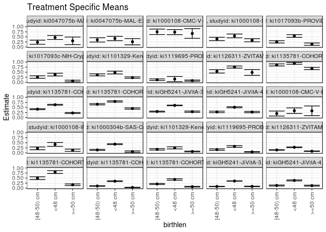

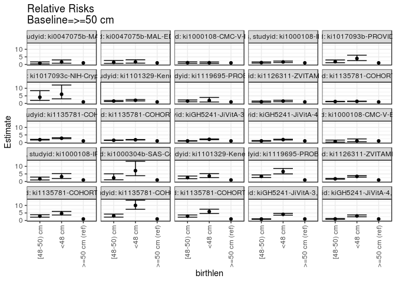

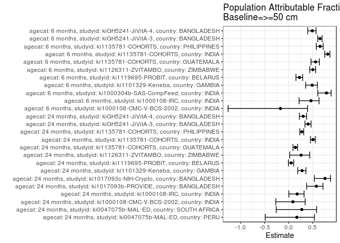

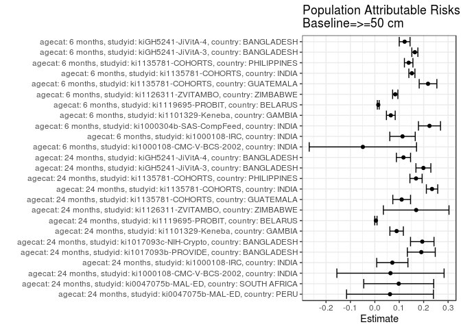

## Results Table

### Parameter: TSM

| agecat | studyid | country | intervention_level | baseline_level | estimate | ci_lower | ci_upper |
| --- | --- | --- | --- | --- | --- | --- | --- |
| 6 months | ki1000108-CMC-V-BCS-2002 | INDIA | >=50 cm | NA | 0.3333333 | 0.0935960 | 0.5730706 |
| 6 months | ki1000108-CMC-V-BCS-2002 | INDIA | <48 cm | NA | 0.3404255 | 0.2042869 | 0.4765642 |
| 6 months | ki1000108-CMC-V-BCS-2002 | INDIA | [48-50) cm | NA | 0.2000000 | 0.0754288 | 0.3245712 |
| 6 months | ki1000108-IRC | INDIA | >=50 cm | NA | 0.1308078 | 0.0746838 | 0.1869319 |
| 6 months | ki1000108-IRC | INDIA | <48 cm | NA | 0.4195096 | 0.3246718 | 0.5143474 |
| 6 months | ki1000108-IRC | INDIA | [48-50) cm | NA | 0.2244507 | 0.1552483 | 0.2936530 |
| 6 months | ki1000304b-SAS-CompFeed | INDIA | >=50 cm | NA | 0.0601029 | 0.0243827 | 0.0958232 |
| 6 months | ki1000304b-SAS-CompFeed | INDIA | <48 cm | NA | 0.4303615 | 0.4101815 | 0.4505416 |
| 6 months | ki1000304b-SAS-CompFeed | INDIA | [48-50) cm | NA | 0.1445683 | 0.1178334 | 0.1713031 |
| 6 months | ki1101329-Keneba | GAMBIA | >=50 cm | NA | 0.0681176 | 0.0488505 | 0.0873847 |
| 6 months | ki1101329-Keneba | GAMBIA | <48 cm | NA | 0.2482438 | 0.1942091 | 0.3022785 |
| 6 months | ki1101329-Keneba | GAMBIA | [48-50) cm | NA | 0.1739585 | 0.1388962 | 0.2090207 |
| 6 months | ki1119695-PROBIT | BELARUS | >=50 cm | NA | 0.0486000 | 0.0348825 | 0.0623175 |
| 6 months | ki1119695-PROBIT | BELARUS | <48 cm | NA | 0.3199160 | 0.2791734 | 0.3606587 |
| 6 months | ki1119695-PROBIT | BELARUS | [48-50) cm | NA | 0.1637847 | 0.1282166 | 0.1993529 |
| 6 months | ki1126311-ZVITAMBO | ZIMBABWE | >=50 cm | NA | 0.0821021 | 0.0710116 | 0.0931925 |
| 6 months | ki1126311-ZVITAMBO | ZIMBABWE | <48 cm | NA | 0.2763626 | 0.2590087 | 0.2937164 |
| 6 months | ki1126311-ZVITAMBO | ZIMBABWE | [48-50) cm | NA | 0.1438048 | 0.1316163 | 0.1559933 |
| 6 months | ki1135781-COHORTS | GUATEMALA | >=50 cm | NA | 0.1701466 | 0.1301652 | 0.2101280 |
| 6 months | ki1135781-COHORTS | GUATEMALA | <48 cm | NA | 0.7965044 | 0.7268415 | 0.8661674 |
| 6 months | ki1135781-COHORTS | GUATEMALA | [48-50) cm | NA | 0.4961587 | 0.4273055 | 0.5650118 |
| 6 months | ki1135781-COHORTS | INDIA | >=50 cm | NA | 0.0346528 | 0.0245126 | 0.0447930 |
| 6 months | ki1135781-COHORTS | INDIA | <48 cm | NA | 0.3460292 | 0.3274535 | 0.3646050 |
| 6 months | ki1135781-COHORTS | INDIA | [48-50) cm | NA | 0.1072969 | 0.0944321 | 0.1201617 |
| 6 months | ki1135781-COHORTS | PHILIPPINES | >=50 cm | NA | 0.0731559 | 0.0567862 | 0.0895256 |
| 6 months | ki1135781-COHORTS | PHILIPPINES | <48 cm | NA | 0.4308320 | 0.3941781 | 0.4674860 |
| 6 months | ki1135781-COHORTS | PHILIPPINES | [48-50) cm | NA | 0.2091449 | 0.1844748 | 0.2338150 |
| 6 months | kiGH5241-JiVitA-3 | BANGLADESH | >=50 cm | NA | 0.0867061 | 0.0747023 | 0.0987099 |
| 6 months | kiGH5241-JiVitA-3 | BANGLADESH | <48 cm | NA | 0.3538120 | 0.3433201 | 0.3643039 |
| 6 months | kiGH5241-JiVitA-3 | BANGLADESH | [48-50) cm | NA | 0.0833776 | 0.0740174 | 0.0927378 |
| 6 months | kiGH5241-JiVitA-4 | BANGLADESH | >=50 cm | NA | 0.1266392 | 0.1031598 | 0.1501186 |
| 6 months | kiGH5241-JiVitA-4 | BANGLADESH | <48 cm | NA | 0.3828412 | 0.3568310 | 0.4088514 |
| 6 months | kiGH5241-JiVitA-4 | BANGLADESH | [48-50) cm | NA | 0.1331850 | 0.1076944 | 0.1586755 |
| 24 months | ki0047075b-MAL-ED | PERU | >=50 cm | NA | 0.3043478 | 0.1158071 | 0.4928886 |
| 24 months | ki0047075b-MAL-ED | PERU | <48 cm | NA | 0.4700000 | 0.3719213 | 0.5680787 |
| 24 months | ki0047075b-MAL-ED | PERU | [48-50) cm | NA | 0.2352941 | 0.1342092 | 0.3363790 |
| 24 months | ki0047075b-MAL-ED | SOUTH AFRICA | >=50 cm | NA | 0.2603021 | 0.1052211 | 0.4153831 |
| 24 months | ki0047075b-MAL-ED | SOUTH AFRICA | <48 cm | NA | 0.4192781 | 0.3125437 | 0.5260124 |
| 24 months | ki0047075b-MAL-ED | SOUTH AFRICA | [48-50) cm | NA | 0.3508918 | 0.2446241 | 0.4571596 |
| 24 months | ki1000108-CMC-V-BCS-2002 | INDIA | >=50 cm | NA | 0.6666667 | 0.4269522 | 0.9063811 |
| 24 months | ki1000108-CMC-V-BCS-2002 | INDIA | <48 cm | NA | 0.7346939 | 0.6104786 | 0.8589091 |
| 24 months | ki1000108-CMC-V-BCS-2002 | INDIA | [48-50) cm | NA | 0.7500000 | 0.6151606 | 0.8848394 |
| 24 months | ki1000108-IRC | INDIA | >=50 cm | NA | 0.3334993 | 0.2556371 | 0.4113615 |
| 24 months | ki1000108-IRC | INDIA | <48 cm | NA | 0.5465392 | 0.4518932 | 0.6411852 |
| 24 months | ki1000108-IRC | INDIA | [48-50) cm | NA | 0.3963093 | 0.3139632 | 0.4786553 |
| 24 months | ki1017093b-PROVIDE | BANGLADESH | >=50 cm | NA | 0.1389310 | 0.0803052 | 0.1975567 |
| 24 months | ki1017093b-PROVIDE | BANGLADESH | <48 cm | NA | 0.5437320 | 0.4754783 | 0.6119857 |
| 24 months | ki1017093b-PROVIDE | BANGLADESH | [48-50) cm | NA | 0.2531594 | 0.1967139 | 0.3096050 |
| 24 months | ki1017093c-NIH-Crypto | BANGLADESH | >=50 cm | NA | 0.0625000 | 0.0205249 | 0.1044751 |
| 24 months | ki1017093c-NIH-Crypto | BANGLADESH | <48 cm | NA | 0.3800000 | 0.3126646 | 0.4473354 |
| 24 months | ki1017093c-NIH-Crypto | BANGLADESH | [48-50) cm | NA | 0.2580645 | 0.1951194 | 0.3210096 |
| 24 months | ki1101329-Keneba | GAMBIA | >=50 cm | NA | 0.2309278 | 0.1949449 | 0.2669107 |
| 24 months | ki1101329-Keneba | GAMBIA | <48 cm | NA | 0.4811297 | 0.4120054 | 0.5502541 |
| 24 months | ki1101329-Keneba | GAMBIA | [48-50) cm | NA | 0.3680613 | 0.3176274 | 0.4184952 |
| 24 months | ki1119695-PROBIT | BELARUS | >=50 cm | NA | 0.0809123 | 0.0513729 | 0.1104517 |
| 24 months | ki1119695-PROBIT | BELARUS | <48 cm | NA | 0.1590909 | 0.0327881 | 0.2853937 |
| 24 months | ki1119695-PROBIT | BELARUS | [48-50) cm | NA | 0.1266234 | 0.0879311 | 0.1653157 |
| 24 months | ki1126311-ZVITAMBO | ZIMBABWE | >=50 cm | NA | 0.4853918 | 0.3417666 | 0.6290171 |
| 24 months | ki1126311-ZVITAMBO | ZIMBABWE | <48 cm | NA | 0.7535851 | 0.7008701 | 0.8063000 |
| 24 months | ki1126311-ZVITAMBO | ZIMBABWE | [48-50) cm | NA | 0.5398520 | 0.4552117 | 0.6244922 |
| 24 months | ki1135781-COHORTS | GUATEMALA | >=50 cm | NA | 0.6818182 | 0.6255834 | 0.7380529 |
| 24 months | ki1135781-COHORTS | GUATEMALA | <48 cm | NA | 0.9338843 | 0.8895703 | 0.9781983 |
| 24 months | ki1135781-COHORTS | GUATEMALA | [48-50) cm | NA | 0.8587571 | 0.8074040 | 0.9101102 |
| 24 months | ki1135781-COHORTS | INDIA | >=50 cm | NA | 0.2283638 | 0.2033650 | 0.2533627 |
| 24 months | ki1135781-COHORTS | INDIA | <48 cm | NA | 0.6352253 | 0.6139155 | 0.6565351 |
| 24 months | ki1135781-COHORTS | INDIA | [48-50) cm | NA | 0.4157715 | 0.3931454 | 0.4383976 |
| 24 months | ki1135781-COHORTS | PHILIPPINES | >=50 cm | NA | 0.4483621 | 0.4163512 | 0.4803730 |
| 24 months | ki1135781-COHORTS | PHILIPPINES | <48 cm | NA | 0.7974388 | 0.7658152 | 0.8290624 |
| 24 months | ki1135781-COHORTS | PHILIPPINES | [48-50) cm | NA | 0.6577028 | 0.6277746 | 0.6876311 |
| 24 months | kiGH5241-JiVitA-3 | BANGLADESH | >=50 cm | NA | 0.2906581 | 0.2579787 | 0.3233374 |
| 24 months | kiGH5241-JiVitA-3 | BANGLADESH | <48 cm | NA | 0.6025896 | 0.5871196 | 0.6180596 |
| 24 months | kiGH5241-JiVitA-3 | BANGLADESH | [48-50) cm | NA | 0.2992214 | 0.2771578 | 0.3212849 |
| 24 months | kiGH5241-JiVitA-4 | BANGLADESH | >=50 cm | NA | 0.2724273 | 0.2387941 | 0.3060605 |
| 24 months | kiGH5241-JiVitA-4 | BANGLADESH | <48 cm | NA | 0.5106369 | 0.4835301 | 0.5377436 |
| 24 months | kiGH5241-JiVitA-4 | BANGLADESH | [48-50) cm | NA | 0.2793539 | 0.2427309 | 0.3159768 |

### Parameter: E(Y)

| agecat | studyid | country | intervention_level | baseline_level | estimate | ci_lower | ci_upper |
| --- | --- | --- | --- | --- | --- | --- | --- |
| 6 months | ki1000108-CMC-V-BCS-2002 | INDIA | NA | NA | 0.2843137 | 0.1963411 | 0.3722864 |
| 6 months | ki1000108-IRC | INDIA | NA | NA | 0.2442159 | 0.2014677 | 0.2869642 |
| 6 months | ki1000304b-SAS-CompFeed | INDIA | NA | NA | 0.2839879 | 0.2652870 | 0.3026888 |
| 6 months | ki1101329-Keneba | GAMBIA | NA | NA | 0.1336303 | 0.1154530 | 0.1518076 |
| 6 months | ki1119695-PROBIT | BELARUS | NA | NA | 0.0626864 | 0.0488489 | 0.0765238 |
| 6 months | ki1126311-ZVITAMBO | ZIMBABWE | NA | NA | 0.1657324 | 0.1576867 | 0.1737781 |
| 6 months | ki1135781-COHORTS | GUATEMALA | NA | NA | 0.3880814 | 0.3516414 | 0.4245214 |
| 6 months | ki1135781-COHORTS | INDIA | NA | NA | 0.1864711 | 0.1767241 | 0.1962180 |
| 6 months | ki1135781-COHORTS | PHILIPPINES | NA | NA | 0.2117734 | 0.1963625 | 0.2271843 |
| 6 months | kiGH5241-JiVitA-3 | BANGLADESH | NA | NA | 0.2506663 | 0.2425523 | 0.2587804 |
| 6 months | kiGH5241-JiVitA-4 | BANGLADESH | NA | NA | 0.2487562 | 0.2326103 | 0.2649022 |
| 24 months | ki0047075b-MAL-ED | PERU | NA | NA | 0.3664921 | 0.2979781 | 0.4350062 |
| 24 months | ki0047075b-MAL-ED | SOUTH AFRICA | NA | NA | 0.3582090 | 0.2917585 | 0.4246594 |
| 24 months | ki1000108-CMC-V-BCS-2002 | INDIA | NA | NA | 0.7307692 | 0.6451085 | 0.8164300 |
| 24 months | ki1000108-IRC | INDIA | NA | NA | 0.4051282 | 0.3563438 | 0.4539126 |
| 24 months | ki1017093b-PROVIDE | BANGLADESH | NA | NA | 0.3292894 | 0.2909105 | 0.3676684 |
| 24 months | ki1017093c-NIH-Crypto | BANGLADESH | NA | NA | 0.2568093 | 0.2190047 | 0.2946140 |
| 24 months | ki1101329-Keneba | GAMBIA | NA | NA | 0.3201878 | 0.2921545 | 0.3482211 |
| 24 months | ki1119695-PROBIT | BELARUS | NA | NA | 0.0852540 | 0.0554439 | 0.1150642 |
| 24 months | ki1126311-ZVITAMBO | ZIMBABWE | NA | NA | 0.6547884 | 0.6107631 | 0.6988137 |
| 24 months | ki1135781-COHORTS | GUATEMALA | NA | NA | 0.7918149 | 0.7582177 | 0.8254122 |
| 24 months | ki1135781-COHORTS | INDIA | NA | NA | 0.4627179 | 0.4485533 | 0.4768825 |
| 24 months | ki1135781-COHORTS | PHILIPPINES | NA | NA | 0.6171171 | 0.5978338 | 0.6364004 |
| 24 months | kiGH5241-JiVitA-3 | BANGLADESH | NA | NA | 0.4895784 | 0.4764028 | 0.5027539 |
| 24 months | kiGH5241-JiVitA-4 | BANGLADESH | NA | NA | 0.3897667 | 0.3711087 | 0.4084248 |

### Parameter: RR

| agecat | studyid | country | intervention_level | baseline_level | estimate | ci_lower | ci_upper |
| --- | --- | --- | --- | --- | --- | --- | --- |
| 6 months | ki1000108-CMC-V-BCS-2002 | INDIA | >=50 cm | >=50 cm | 1.0000000 | 1.0000000 | 1.000000 |
| 6 months | ki1000108-CMC-V-BCS-2002 | INDIA | <48 cm | >=50 cm | 1.0212766 | 0.4484926 | 2.325581 |
| 6 months | ki1000108-CMC-V-BCS-2002 | INDIA | [48-50) cm | >=50 cm | 0.6000000 | 0.2317135 | 1.553643 |
| 6 months | ki1000108-IRC | INDIA | >=50 cm | >=50 cm | 1.0000000 | 1.0000000 | 1.000000 |
| 6 months | ki1000108-IRC | INDIA | <48 cm | >=50 cm | 3.2070677 | 1.9702081 | 5.220404 |
| 6 months | ki1000108-IRC | INDIA | [48-50) cm | >=50 cm | 1.7158807 | 1.0123054 | 2.908457 |
| 6 months | ki1000304b-SAS-CompFeed | INDIA | >=50 cm | >=50 cm | 1.0000000 | 1.0000000 | 1.000000 |
| 6 months | ki1000304b-SAS-CompFeed | INDIA | <48 cm | >=50 cm | 7.1604072 | 3.8347754 | 13.370126 |
| 6 months | ki1000304b-SAS-CompFeed | INDIA | [48-50) cm | >=50 cm | 2.4053449 | 1.1378268 | 5.084855 |
| 6 months | ki1101329-Keneba | GAMBIA | >=50 cm | >=50 cm | 1.0000000 | 1.0000000 | 1.000000 |
| 6 months | ki1101329-Keneba | GAMBIA | <48 cm | >=50 cm | 3.6443413 | 2.5524605 | 5.203302 |
| 6 months | ki1101329-Keneba | GAMBIA | [48-50) cm | >=50 cm | 2.5537959 | 1.8060174 | 3.611191 |
| 6 months | ki1119695-PROBIT | BELARUS | >=50 cm | >=50 cm | 1.0000000 | 1.0000000 | 1.000000 |
| 6 months | ki1119695-PROBIT | BELARUS | <48 cm | >=50 cm | 6.5826283 | 5.0201542 | 8.631407 |
| 6 months | ki1119695-PROBIT | BELARUS | [48-50) cm | >=50 cm | 3.3700528 | 2.6241123 | 4.328037 |
| 6 months | ki1126311-ZVITAMBO | ZIMBABWE | >=50 cm | >=50 cm | 1.0000000 | 1.0000000 | 1.000000 |
| 6 months | ki1126311-ZVITAMBO | ZIMBABWE | <48 cm | >=50 cm | 3.3660859 | 2.9006250 | 3.906239 |
| 6 months | ki1126311-ZVITAMBO | ZIMBABWE | [48-50) cm | >=50 cm | 1.7515369 | 1.4936141 | 2.053999 |
| 6 months | ki1135781-COHORTS | GUATEMALA | >=50 cm | >=50 cm | 1.0000000 | 1.0000000 | 1.000000 |
| 6 months | ki1135781-COHORTS | GUATEMALA | <48 cm | >=50 cm | 4.6812826 | 3.6425268 | 6.016265 |
| 6 months | ki1135781-COHORTS | GUATEMALA | [48-50) cm | >=50 cm | 2.9160653 | 2.2208686 | 3.828879 |
| 6 months | ki1135781-COHORTS | INDIA | >=50 cm | >=50 cm | 1.0000000 | 1.0000000 | 1.000000 |
| 6 months | ki1135781-COHORTS | INDIA | <48 cm | >=50 cm | 9.9856081 | 7.4171035 | 13.443573 |
| 6 months | ki1135781-COHORTS | INDIA | [48-50) cm | >=50 cm | 3.0963406 | 2.2573527 | 4.247154 |
| 6 months | ki1135781-COHORTS | PHILIPPINES | >=50 cm | >=50 cm | 1.0000000 | 1.0000000 | 1.000000 |
| 6 months | ki1135781-COHORTS | PHILIPPINES | <48 cm | >=50 cm | 5.8892306 | 4.6384853 | 7.477233 |
| 6 months | ki1135781-COHORTS | PHILIPPINES | [48-50) cm | >=50 cm | 2.8588929 | 2.2221459 | 3.678097 |
| 6 months | kiGH5241-JiVitA-3 | BANGLADESH | >=50 cm | >=50 cm | 1.0000000 | 1.0000000 | 1.000000 |
| 6 months | kiGH5241-JiVitA-3 | BANGLADESH | <48 cm | >=50 cm | 4.0805905 | 3.5492182 | 4.691517 |
| 6 months | kiGH5241-JiVitA-3 | BANGLADESH | [48-50) cm | >=50 cm | 0.9616121 | 0.8055152 | 1.147958 |
| 6 months | kiGH5241-JiVitA-4 | BANGLADESH | >=50 cm | >=50 cm | 1.0000000 | 1.0000000 | 1.000000 |
| 6 months | kiGH5241-JiVitA-4 | BANGLADESH | <48 cm | >=50 cm | 3.0230864 | 2.4812410 | 3.683258 |
| 6 months | kiGH5241-JiVitA-4 | BANGLADESH | [48-50) cm | >=50 cm | 1.0516885 | 0.8104428 | 1.364746 |
| 24 months | ki0047075b-MAL-ED | PERU | >=50 cm | >=50 cm | 1.0000000 | 1.0000000 | 1.000000 |
| 24 months | ki0047075b-MAL-ED | PERU | <48 cm | >=50 cm | 1.5442857 | 0.8032154 | 2.969090 |
| 24 months | ki0047075b-MAL-ED | PERU | [48-50) cm | >=50 cm | 0.7731092 | 0.3637769 | 1.643034 |
| 24 months | ki0047075b-MAL-ED | SOUTH AFRICA | >=50 cm | >=50 cm | 1.0000000 | 1.0000000 | 1.000000 |
| 24 months | ki0047075b-MAL-ED | SOUTH AFRICA | <48 cm | >=50 cm | 1.6107365 | 0.8463596 | 3.065449 |
| 24 months | ki0047075b-MAL-ED | SOUTH AFRICA | [48-50) cm | >=50 cm | 1.3480177 | 0.6931501 | 2.621585 |
| 24 months | ki1000108-CMC-V-BCS-2002 | INDIA | >=50 cm | >=50 cm | 1.0000000 | 1.0000000 | 1.000000 |
| 24 months | ki1000108-CMC-V-BCS-2002 | INDIA | <48 cm | >=50 cm | 1.1020408 | 0.7406898 | 1.639679 |
| 24 months | ki1000108-CMC-V-BCS-2002 | INDIA | [48-50) cm | >=50 cm | 1.1250000 | 0.7525933 | 1.681685 |
| 24 months | ki1000108-IRC | INDIA | >=50 cm | >=50 cm | 1.0000000 | 1.0000000 | 1.000000 |
| 24 months | ki1000108-IRC | INDIA | <48 cm | >=50 cm | 1.6388015 | 1.2242747 | 2.193683 |
| 24 months | ki1000108-IRC | INDIA | [48-50) cm | >=50 cm | 1.1883361 | 0.8687676 | 1.625455 |
| 24 months | ki1017093b-PROVIDE | BANGLADESH | >=50 cm | >=50 cm | 1.0000000 | 1.0000000 | 1.000000 |
| 24 months | ki1017093b-PROVIDE | BANGLADESH | <48 cm | >=50 cm | 3.9136848 | 2.5194303 | 6.079521 |
| 24 months | ki1017093b-PROVIDE | BANGLADESH | [48-50) cm | >=50 cm | 1.8221960 | 1.1307949 | 2.936340 |
| 24 months | ki1017093c-NIH-Crypto | BANGLADESH | >=50 cm | >=50 cm | 1.0000000 | 1.0000000 | 1.000000 |
| 24 months | ki1017093c-NIH-Crypto | BANGLADESH | <48 cm | >=50 cm | 6.0800000 | 3.0356333 | 12.177492 |
| 24 months | ki1017093c-NIH-Crypto | BANGLADESH | [48-50) cm | >=50 cm | 4.1290323 | 2.0208559 | 8.436479 |
| 24 months | ki1101329-Keneba | GAMBIA | >=50 cm | >=50 cm | 1.0000000 | 1.0000000 | 1.000000 |
| 24 months | ki1101329-Keneba | GAMBIA | <48 cm | >=50 cm | 2.0834639 | 1.6858163 | 2.574908 |
| 24 months | ki1101329-Keneba | GAMBIA | [48-50) cm | >=50 cm | 1.5938372 | 1.2971269 | 1.958418 |
| 24 months | ki1119695-PROBIT | BELARUS | >=50 cm | >=50 cm | 1.0000000 | 1.0000000 | 1.000000 |
| 24 months | ki1119695-PROBIT | BELARUS | <48 cm | >=50 cm | 1.9662142 | 0.9709023 | 3.981861 |
| 24 months | ki1119695-PROBIT | BELARUS | [48-50) cm | >=50 cm | 1.5649460 | 1.0753775 | 2.277392 |
| 24 months | ki1126311-ZVITAMBO | ZIMBABWE | >=50 cm | >=50 cm | 1.0000000 | 1.0000000 | 1.000000 |
| 24 months | ki1126311-ZVITAMBO | ZIMBABWE | <48 cm | >=50 cm | 1.5525293 | 1.1449993 | 2.105108 |
| 24 months | ki1126311-ZVITAMBO | ZIMBABWE | [48-50) cm | >=50 cm | 1.1121983 | 0.7953553 | 1.555261 |
| 24 months | ki1135781-COHORTS | GUATEMALA | >=50 cm | >=50 cm | 1.0000000 | 1.0000000 | 1.000000 |
| 24 months | ki1135781-COHORTS | GUATEMALA | <48 cm | >=50 cm | 1.3696970 | 1.2453742 | 1.506431 |
| 24 months | ki1135781-COHORTS | GUATEMALA | [48-50) cm | >=50 cm | 1.2595104 | 1.1375172 | 1.394587 |
| 24 months | ki1135781-COHORTS | INDIA | >=50 cm | >=50 cm | 1.0000000 | 1.0000000 | 1.000000 |
| 24 months | ki1135781-COHORTS | INDIA | <48 cm | >=50 cm | 2.7816369 | 2.4817750 | 3.117730 |
| 24 months | ki1135781-COHORTS | INDIA | [48-50) cm | >=50 cm | 1.8206537 | 1.6124258 | 2.055772 |
| 24 months | ki1135781-COHORTS | PHILIPPINES | >=50 cm | >=50 cm | 1.0000000 | 1.0000000 | 1.000000 |
| 24 months | ki1135781-COHORTS | PHILIPPINES | <48 cm | >=50 cm | 1.7785598 | 1.6400600 | 1.928756 |
| 24 months | ki1135781-COHORTS | PHILIPPINES | [48-50) cm | >=50 cm | 1.4669011 | 1.3489508 | 1.595165 |
| 24 months | kiGH5241-JiVitA-3 | BANGLADESH | >=50 cm | >=50 cm | 1.0000000 | 1.0000000 | 1.000000 |
| 24 months | kiGH5241-JiVitA-3 | BANGLADESH | <48 cm | >=50 cm | 2.0731907 | 1.8490715 | 2.324474 |
| 24 months | kiGH5241-JiVitA-3 | BANGLADESH | [48-50) cm | >=50 cm | 1.0294618 | 0.9005813 | 1.176786 |
| 24 months | kiGH5241-JiVitA-4 | BANGLADESH | >=50 cm | >=50 cm | 1.0000000 | 1.0000000 | 1.000000 |
| 24 months | kiGH5241-JiVitA-4 | BANGLADESH | <48 cm | >=50 cm | 1.8743968 | 1.6402375 | 2.141985 |
| 24 months | kiGH5241-JiVitA-4 | BANGLADESH | [48-50) cm | >=50 cm | 1.0254255 | 0.8580080 | 1.225510 |

### Parameter: PAR

| agecat | studyid | country | intervention_level | baseline_level | estimate | ci_lower | ci_upper |
| --- | --- | --- | --- | --- | --- | --- | --- |
| 6 months | ki1000108-CMC-V-BCS-2002 | INDIA | >=50 cm | NA | -0.0490196 | -0.2688128 | 0.1707736 |
| 6 months | ki1000108-IRC | INDIA | >=50 cm | NA | 0.1134081 | 0.0613248 | 0.1654913 |
| 6 months | ki1000304b-SAS-CompFeed | INDIA | >=50 cm | NA | 0.2238850 | 0.1786904 | 0.2690795 |
| 6 months | ki1101329-Keneba | GAMBIA | >=50 cm | NA | 0.0655127 | 0.0475491 | 0.0834763 |
| 6 months | ki1119695-PROBIT | BELARUS | >=50 cm | NA | 0.0140863 | 0.0103911 | 0.0177815 |
| 6 months | ki1126311-ZVITAMBO | ZIMBABWE | >=50 cm | NA | 0.0836303 | 0.0728719 | 0.0943888 |
| 6 months | ki1135781-COHORTS | GUATEMALA | >=50 cm | NA | 0.2179348 | 0.1817446 | 0.2541249 |
| 6 months | ki1135781-COHORTS | INDIA | >=50 cm | NA | 0.1518183 | 0.1393872 | 0.1642494 |
| 6 months | ki1135781-COHORTS | PHILIPPINES | >=50 cm | NA | 0.1386175 | 0.1211940 | 0.1560410 |
| 6 months | kiGH5241-JiVitA-3 | BANGLADESH | >=50 cm | NA | 0.1639603 | 0.1516224 | 0.1762981 |
| 6 months | kiGH5241-JiVitA-4 | BANGLADESH | >=50 cm | NA | 0.1221170 | 0.1000023 | 0.1442318 |
| 24 months | ki0047075b-MAL-ED | PERU | >=50 cm | NA | 0.0621443 | -0.1158461 | 0.2401347 |
| 24 months | ki0047075b-MAL-ED | SOUTH AFRICA | >=50 cm | NA | 0.0979069 | -0.0453962 | 0.2412099 |
| 24 months | ki1000108-CMC-V-BCS-2002 | INDIA | >=50 cm | NA | 0.0641026 | -0.1554992 | 0.2837043 |
| 24 months | ki1000108-IRC | INDIA | >=50 cm | NA | 0.0716289 | 0.0077219 | 0.1355359 |
| 24 months | ki1017093b-PROVIDE | BANGLADESH | >=50 cm | NA | 0.1903585 | 0.1332298 | 0.2474871 |
| 24 months | ki1017093c-NIH-Crypto | BANGLADESH | >=50 cm | NA | 0.1943093 | 0.1462097 | 0.2424089 |
| 24 months | ki1101329-Keneba | GAMBIA | >=50 cm | NA | 0.0892600 | 0.0616764 | 0.1168435 |
| 24 months | ki1119695-PROBIT | BELARUS | >=50 cm | NA | 0.0043417 | -0.0002862 | 0.0089697 |
| 24 months | ki1126311-ZVITAMBO | ZIMBABWE | >=50 cm | NA | 0.1693966 | 0.0349944 | 0.3037988 |
| 24 months | ki1135781-COHORTS | GUATEMALA | >=50 cm | NA | 0.1099968 | 0.0736637 | 0.1463298 |
| 24 months | ki1135781-COHORTS | INDIA | >=50 cm | NA | 0.2343541 | 0.2110813 | 0.2576269 |
| 24 months | ki1135781-COHORTS | PHILIPPINES | >=50 cm | NA | 0.1687550 | 0.1437425 | 0.1937675 |
| 24 months | kiGH5241-JiVitA-3 | BANGLADESH | >=50 cm | NA | 0.1989203 | 0.1683871 | 0.2294535 |
| 24 months | kiGH5241-JiVitA-4 | BANGLADESH | >=50 cm | NA | 0.1173394 | 0.0883051 | 0.1463738 |

### Parameter: PAF

| agecat | studyid | country | intervention_level | baseline_level | estimate | ci_lower | ci_upper |
| --- | --- | --- | --- | --- | --- | --- | --- |
| 6 months | ki1000108-CMC-V-BCS-2002 | INDIA | >=50 cm | NA | -0.1724138 | -1.2667265 | 0.3935951 |
| 6 months | ki1000108-IRC | INDIA | >=50 cm | NA | 0.4643763 | 0.2173446 | 0.6334367 |
| 6 months | ki1000304b-SAS-CompFeed | INDIA | >=50 cm | NA | 0.7883609 | 0.6073484 | 0.8859266 |
| 6 months | ki1101329-Keneba | GAMBIA | >=50 cm | NA | 0.4902533 | 0.3529630 | 0.5984129 |
| 6 months | ki1119695-PROBIT | BELARUS | >=50 cm | NA | 0.2247112 | 0.1509442 | 0.2920693 |
| 6 months | ki1126311-ZVITAMBO | ZIMBABWE | >=50 cm | NA | 0.5046107 | 0.4393535 | 0.5622722 |
| 6 months | ki1135781-COHORTS | GUATEMALA | >=50 cm | NA | 0.5615697 | 0.4651039 | 0.6406384 |
| 6 months | ki1135781-COHORTS | INDIA | >=50 cm | NA | 0.8141653 | 0.7526957 | 0.8603561 |
| 6 months | ki1135781-COHORTS | PHILIPPINES | >=50 cm | NA | 0.6545557 | 0.5756383 | 0.7187971 |
| 6 months | kiGH5241-JiVitA-3 | BANGLADESH | >=50 cm | NA | 0.6540977 | 0.6050863 | 0.6970264 |
| 6 months | kiGH5241-JiVitA-4 | BANGLADESH | >=50 cm | NA | 0.4909105 | 0.3975770 | 0.5697838 |
| 24 months | ki0047075b-MAL-ED | PERU | >=50 cm | NA | 0.1695652 | -0.4902903 | 0.5372567 |
| 24 months | ki0047075b-MAL-ED | SOUTH AFRICA | >=50 cm | NA | 0.2733233 | -0.2615874 | 0.5814329 |
| 24 months | ki1000108-CMC-V-BCS-2002 | INDIA | >=50 cm | NA | 0.0877193 | -0.2691613 | 0.3442472 |
| 24 months | ki1000108-IRC | INDIA | >=50 cm | NA | 0.1768055 | 0.0028532 | 0.3204118 |
| 24 months | ki1017093b-PROVIDE | BANGLADESH | >=50 cm | NA | 0.5780886 | 0.3740073 | 0.7156369 |
| 24 months | ki1017093c-NIH-Crypto | BANGLADESH | >=50 cm | NA | 0.7566288 | 0.5354111 | 0.8725119 |
| 24 months | ki1101329-Keneba | GAMBIA | >=50 cm | NA | 0.2787739 | 0.1878558 | 0.3595139 |
| 24 months | ki1119695-PROBIT | BELARUS | >=50 cm | NA | 0.0509269 | -0.0054685 | 0.1041592 |
| 24 months | ki1126311-ZVITAMBO | ZIMBABWE | >=50 cm | NA | 0.2587043 | 0.0200316 | 0.4392479 |
| 24 months | ki1135781-COHORTS | GUATEMALA | >=50 cm | NA | 0.1389173 | 0.0896167 | 0.1855481 |
| 24 months | ki1135781-COHORTS | INDIA | >=50 cm | NA | 0.5064729 | 0.4539350 | 0.5539560 |
| 24 months | ki1135781-COHORTS | PHILIPPINES | >=50 cm | NA | 0.2734570 | 0.2305822 | 0.3139427 |
| 24 months | kiGH5241-JiVitA-3 | BANGLADESH | >=50 cm | NA | 0.4063095 | 0.3400591 | 0.4659091 |
| 24 months | kiGH5241-JiVitA-4 | BANGLADESH | >=50 cm | NA | 0.3010504 | 0.2217828 | 0.3722440 |